# Applied Ecology at Harper Adams University

## Applied Ecology at Harper Adams University

Postgraduate induction

**Dr Ben Clunie**Entomology, integrated pest management and biological recording

## Applied ecologists are a ‘vulnerable species’

Fewer opportunities for plant and field studies

An ageing workforce and gaps in succession planning

A continuing need for specialist ecological skills

Training supports the delivery of biodiversity goals.

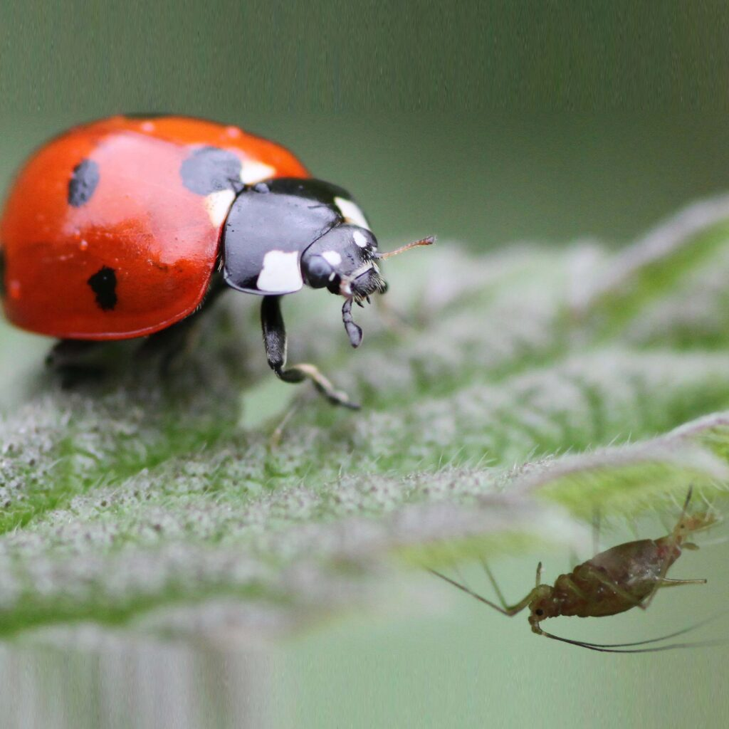

Understanding organisms supports informed management.

[NERC skills review](https://www.ukri.org/who-we-are/nerc/our-policies-and-standards/postgraduate-policy-and-strategy/skills-review/)Environmental Audit CommitteeCIEEM / Lantra (2023)

## Our postgraduate courses

EntomologyInsect biology, diversity and applicationsIntegrated pest managementEvidence for sustainable crop protectionBiological recordingSurveying, monitoring and analysis

Select a course to jump to its structure, or continue through the slides.

## Programme organisation

### Admissions and student records

**Heather Hogan · PC104**  
Administration, registration, timetabling, schedules and applications

### Subject co-ordinator

**Dr Ben Clunie · Jean Jackson Entomology Building**  
Course design, subject guidance and postgraduate student support

### Programmes manager

**Dr Mitch Crook · PC105**  
Consistency, quality and fairness across postgraduate provision

If you are unsure who to ask, start with your subject co-ordinator.

## Entomology

### PgC60 credits

- Skills in Applied Ecology
- Fundamentals of Entomology
- Insect Systematics and Diversity
- Biological Control

### PgD120 credits in total

PgC study plus a further 60 credits

- Experimental Design and Analysis
- Insect Physiology and Behaviour
- Human Insect Interactions
- Insect Ecology and Conservation

### MSc180 credits in total

PgD study plus

Masters Research Project

60 credits

A typical 15-credit module represents 150 hours of study: 30 taught and 120 independent.

## Integrated pest management

### PgC60 credits

- Skills in Applied Ecology
- Pest Biology
- Crop Management Principles
- Crop Management Practice

### PgD120 credits in total

PgC study plus a further 60 credits

- Biological Control
- Plant Protection Products
- Experimental Design and Analysis

One option shown in this overview

- Regenerative Agriculture
- Forestry Management
- Human Insect Interactions

### MSc180 credits in total

PgD study plus

Masters Research Project

60 credits

Use the programme handbook for module credits and the approved choice of options.

## Biological recording

### PgC60 credits

Biological Recording

- Biological Recording and Surveying (15 credits)
- Botanical Skills with FSC (10 credits)
- 35 credits of optional modules across HAU and FSC

### PgD120 credits in total

Biological Recording

PgC study plus

### MSc180 credits in total

Biological Recording

PgD study plus

Masters Research Project

60 credits

Approximately 10 hours of study per credit. FSC: Field Studies Council.

## Assessment and support

Before **15:00**

### Thursday deadlines for Level 7

Submit electronically through the Learning Hub.

Always check the date and time in your assessment brief.

### Plan your submission

- Allow time between the assignment launch and deadline.
- Late work submitted within 5 working days is normally capped at 40%.
- Discuss difficulties with Ben as soon as possible.

Raise a problem early so that support and any valid mitigation can be considered.

## Student support at Harper Adams

### Wellbeing and mental health

Counselling, confidential mental health support and advice on settling into university life.

### Academic skills

Support with writing, referencing, study strategies, time management, maths and statistics.

### Disability and learning needs

Specialist dyslexia support, assistive technology and guidance on study needs and adjustments.

### Money, housing and careers

Housing, finances, careers and placements, with advice for international students.

### Health, faith and community

Local healthcare, chaplaincy and places of worship, plus the Students’ Union.

### IT and changes to study

University systems, campus problem reporting and guidance on breaks in study.

Student Services in the Faccenda student centre can help you find the right team.

[Harper Adams student support ↗](https://www.harper-adams.ac.uk/study/820/university-life/student-support/)

## Student support: useful links

Select a service to open its current information in a new tab.

[**Wellbeing advice ↗**Settling in and everyday wellbeing](https://www.harper-adams.ac.uk/study/1370/university-life/wellbeing/)[**Counselling ↗**The counselling service and how to access it](https://www.harper-adams.ac.uk/study/1373/university-life/counselling-service/)[**Mental health support ↗**Confidential advice and routes to support](https://www.harper-adams.ac.uk/study/1372/university-life/mental-health/)[**Emergency help ↗**Campus contacts and help outside office hours](https://www.harper-adams.ac.uk/study/1333/university-life/emergency-help/)

[**Academic support ↗**Study skills, writing, maths and statistics](https://www.harper-adams.ac.uk/study/1203/university-life/academic-support/)[**Disability support ↗**Learning needs, access and adjustments](https://www.harper-adams.ac.uk/study/1204/university-life/disability-support/)[**Financial support ↗**Help and eligibility during financial hardship](https://www.harper-adams.ac.uk/study/1081/finance/financial-support/)[**IT support ↗**Wi-Fi, email, printing and university systems](https://www.harper-adams.ac.uk/study/1237/university-life/it-support/)

[Full student-support directory ↗ Health services, faith, study breaks and more](https://www.harper-adams.ac.uk/study/820/university-life/student-support/)

## Places to study and carry out research

### Useful places to find

- 23Faccenda Student CentreStudent support and Graze Café
- 22Bamford Library
- 26Jean Jackson Entomology Building
- 56Jean Jackson GlasshouseCrop & Environment Research Centre
- 46Farm Seminar RoomBecomes Simon Leather Entomology Building at the end of September 2026

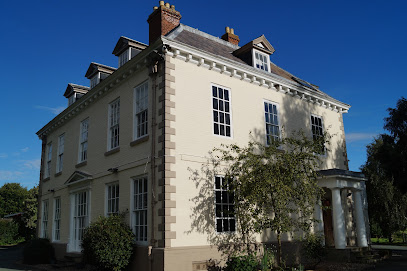

FSC Preston Montford

## Laboratory and field facilities

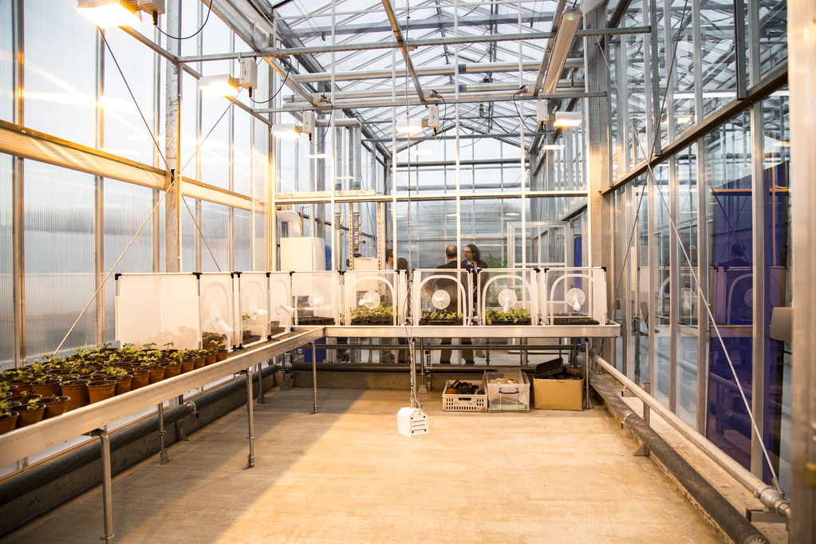

Jean Jackson glasshouse

### Cultures and controlled environments

Fitotron rooms, aphid cultures and biological control cultures

### Behaviour and feeding

Olfactometry, Noldus EthoVision and Observer, electrical penetration graph

### Chemical and molecular work

GC–MS and Nanopore MinION

### Applied experiments

Field and glasshouse trials

## Research at Harper Adams

Explore the groups, people and questions behind the research.

Research groups and staffApplied entomologyEcology, evolution and conservation

## Our research groups

### Applied Entomology Group ↗

Group lead**Prof Tom Pope**

- Dr Joe Roberts
- Dr Ben Clunie
- Nikoletta Foskolou
- Dr Laura Martinez Chavez
- Dr Claire Price

### Ecology, Evolution & Conservation ↗

Group lead**Dr Simon Segar**

- Dr Jack Bamber
- Dr Heather Campbell
- Dr Julia Casperd
- Dr Andrew Cherrill (visiting researcher)
- Dr Matthew Hill
- Professor Nicola Randall
- Dr Ellen Williams

Staff and visiting researchers · Select a group to explore its live page.

## Applied entomology

Insect biology, ecology and sustainable pest management

Chemical ecology, biopesticides, biological control, plant–insect interactions and agroecology

[Open the live research group page ↗](https://www.harper-adams.ac.uk/research/966/research-centre/entomology-group/)

Return to this presentation tab to continue.

### Forming your own project

Choose a research highlight from the website.

## Applied entomology: group overview

### Sustainable crop protection

The group studies insects and other invertebrates to improve pest management in crops, using integrated pest management to reduce reliance on synthetic pesticides.

### Expertise and tools

Expertise spans insect behaviour, taxonomy, molecular biology and analytical chemistry. The team develops biological controls and biopesticides alongside tools for pest monitoring and management.

### Laboratory to field

Research spans molecular experiments, glasshouse trials and field studies, with growers, industry, policy makers and research partners in the UK and overseas.

[Harper Adams research-group overview ↗](https://www.harper-adams.ac.uk/research/966/research-centre/entomology-group/)

## Ecology, evolution and conservation

Understanding biodiversity and its response to environmental change

Insect ecology, evolution and conservation, molecular ecology and biological monitoring

[Open the live research group page ↗](https://www.harper-adams.ac.uk/research/1307/research-centre/ecology-evolution-and-conservation-group/)

Return to this presentation tab to continue.

### Forming your own project

Choose a research highlight from the website.

## Ecology and conservation: group overview

### Biodiversity and environmental change

The group investigates the ecological and evolutionary processes behind biodiversity, and how organisms respond to environmental change.

### Conservation and management

Research supports habitat and population management, the protection of ecosystem services, and understanding of people’s relationships with nature, including biodiversity in urban landscapes.

### A broad range of approaches

Field surveys, molecular ecology, citizen science and statistical modelling support studies of plants and animals across local, regional and global scales.

[Harper Adams research-group overview ↗](https://www.harper-adams.ac.uk/research/1307/research-centre/ecology-evolution-and-conservation-group/)

## Research connections

Organisations with existing or historical partnerships

[figure not shown]

[figure not shown]

[figure not shown]

[figure not shown]

[figure not shown]

[figure not shown]

[figure not shown]

[figure not shown]

## Industry and applied research

Organisations with existing or historical partnerships

[figure not shown]

[figure not shown]

[figure not shown]

[figure not shown]

[figure not shown]

[figure not shown]

[figure not shown]

[figure not shown]

[figure not shown]

[figure not shown]

[figure not shown]

## Your research interests

Where do your interests fit?

Explore the broad themes in either research group.

Applied entomology overviewEcology and conservation overview

### Your interests

Which organisms, habitats or challenges interest you?

### Your experience

Which skills would you like to build on or develop?

### The next conversation

Who could help you develop the idea?

## Questions?

Thank you for your attention.

[Entomology Group ↗](https://www.harper-adams.ac.uk/research/966/research-centre/entomology-group/)[Ecology, Evolution and Conservation Group ↗](https://www.harper-adams.ac.uk/research/1307/research-centre/ecology-evolution-and-conservation-group/)